# Statistik Diagramme

Sanja Perovic, Julia Zerrweck

8/6/2020

```r
library(readr)
library(ggplot2)
library(tidyverse)
df <- read_csv("responses.csv")
```

```r
glimpse(df)
```

```
## Rows: 1,010
## Columns: 150
## $ Music                            <dbl> 5, 4, 5, 5, 5, 5, 5, 5, 5, 5, 5, 5, …
## $ `Slow songs or fast songs`       <dbl> 3, 4, 5, 3, 3, 3, 5, 3, 3, 3, 3, 3, …
## $ Dance                            <dbl> 2, 2, 2, 2, 4, 2, 5, 3, 3, 2, 3, 1, …
## $ Folk                             <dbl> 1, 1, 2, 1, 3, 3, 3, 2, 1, 5, 2, 1, …
## $ Country                          <dbl> 2, 1, 3, 1, 2, 2, 1, 1, 1, 2, 1, 1, …
## $ `Classical music`                <dbl> 2, 1, 4, 1, 4, 3, 2, 2, 2, 2, 2, 4, …
## $ Musical                          <dbl> 1, 2, 5, 1, 3, 3, 2, 2, 4, 5, 3, 1, …
## $ Pop                              <dbl> 5, 3, 3, 2, 5, 2, 5, 4, 3, 3, 4, 2, …
## $ Rock                             <dbl> 5, 5, 5, 2, 3, 5, 3, 5, 5, 5, 3, 5, …
## $ `Metal or Hardrock`              <dbl> 1, 4, 3, 1, 1, 5, 1, 1, 5, 2, 2, 1, …
## $ Punk                             <dbl> 1, 4, 4, 4, 2, 3, 1, 2, 1, 3, 1, 1, …
## $ `Hiphop, Rap`                    <dbl> 1, 1, 1, 2, 5, 4, 3, 3, 1, 2, 3, 1, …
## $ `Reggae, Ska`                    <dbl> 1, 3, 4, 2, 3, 3, 1, 2, 2, 4, 2, 1, …
```

[output cut: 137 more lines]

```r
df <- drop_na(df)
```

# Histogramme

## Histogramm 1

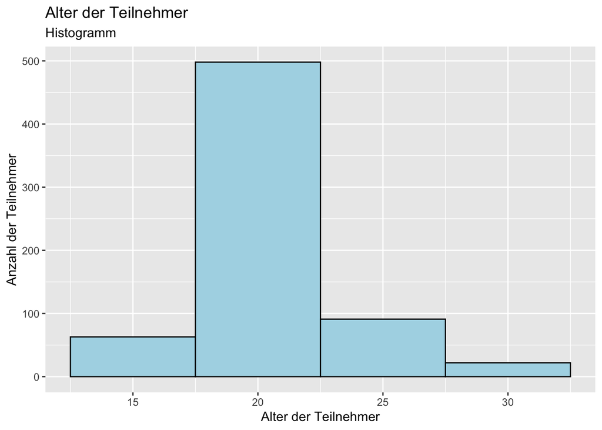

```r
ggplot(df, aes( x = Age)) +
                geom_histogram(binwidth = 5, color= "black", fill = "lightblue") +
                  labs(title="Alter der Teilnehmer",
                       subtitle="Histogramm")+
                  xlab("Alter der Teilnehmer") +
                  ylab("Anzahl der Teilnehmer")
```

Das Alter der Teilnehmer liegt zwischen 15 und 30 Jahren, wobei die Mehrheit der Befragten Anfang 20 ist.

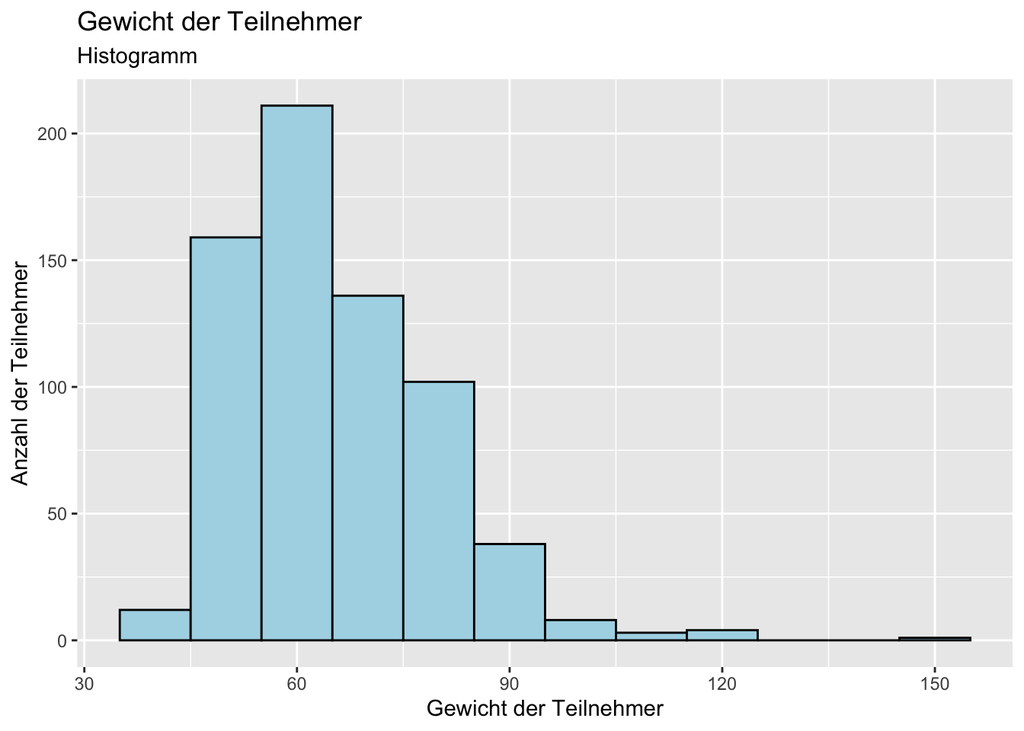

```r
ggplot(df, aes( x = Weight)) +
                geom_histogram(binwidth = 10, color= "black", fill = "lightblue") +
                  labs(title="Gewicht der Teilnehmer",
                       subtitle="Histogramm")+
                  xlab("Gewicht der Teilnehmer") +
                  ylab("Anzahl der Teilnehmer")
```

Das Gewicht der Teilnehmer erstreckt sich bis zu 150kg. Allerdings sind im Schnitt die meisten Teilnehmer um die 60kg schwer.

# Barplots

## Barplot 1

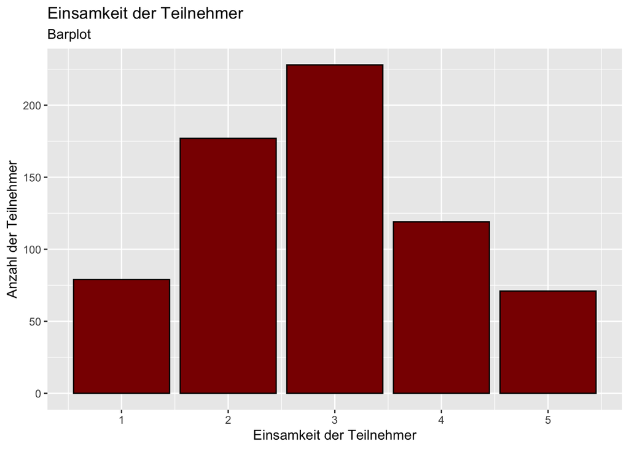

```r
ggplot(df, aes( x = Loneliness)) +
  geom_bar(fill = "darkred", color = "black") +
  labs(title="Einsamkeit der Teilnehmer",
       subtitle="Barplot")+
  xlab("Einsamkeit der Teilnehmer") +
  ylab("Anzahl der Teilnehmer")
```

5 Kategorien der Einsamkeit: die meisten Teilnehmer gaben an, dass sie sich wenig bis mittelmäßig einsam fühlen.

## Barplot 2

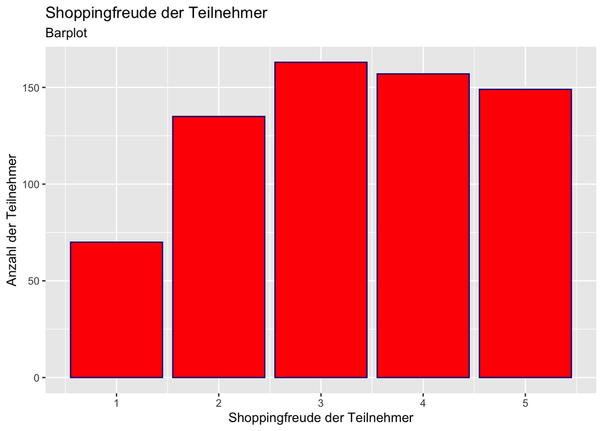

```r
ggplot(df, aes( x = Shopping)) +
  geom_bar(fill = "Red", color = "Darkblue") +
  labs(title="Shoppingfreude der Teilnehmer",
       subtitle="Barplot")+
  xlab("Shoppingfreude der Teilnehmer") +
  ylab("Anzahl der Teilnehmer")
```

Es ist deutlich zu sehen, dass die Angaben sich kaum unterscheiden: nur eine kleine Anzahl gab an, dass sie nicht so gerne shoppen geht. Dem Rest kann man eine mittelmäßige bis hohe Shoppingfreude zuschreiben.

# Faceted Barplot

## Facedet Barplot 1

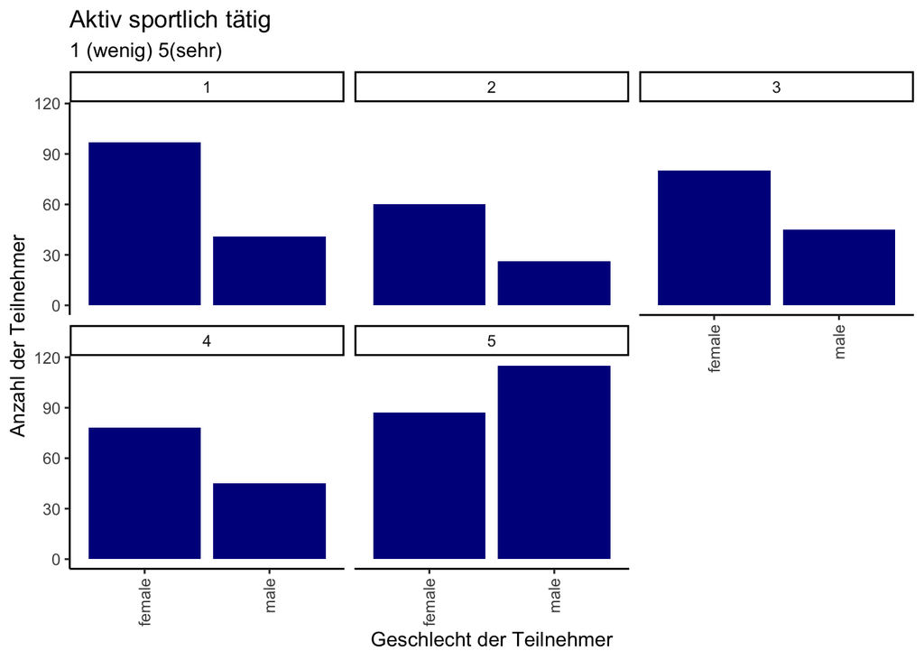

```r
ggplot(df, aes( x = Gender)) + # Entfernung von fill
  geom_bar( position = "dodge", fill= "darkblue") +
  facet_wrap(~ df$`Active sport` ) + # Getrennte Darstellung der Ausprägungen
  ggtitle("Aktiv sportlich tätig", "1 (wenig) 5(sehr)") +
  xlab("Geschlecht der Teilnehmer") +
  ylab("Anzahl der Teilnehmer") +
  theme_classic() +
  theme(legend.title = element_blank()) +
  theme(axis.text.x = element_text(angle = 90,
                                   vjust = 0.5,
                                   hjust=  1))
```

Aktive sportliche Tätogkeit nach Geschlecht: Man kann deutlich sehen, dass die meisten Männer angegeben haben, dass sie sehr häufig sportlich aktiv sind, während die Frauen in den Kategorien 1-4 dominieren. Vor allem bei dere niedrigsten Kategorie (1) dominieren die Frauen mit einem sehr hohen Anteil. Sie sind also weniger sportlich aktiv als Männer.

## Facedet Barplot 2

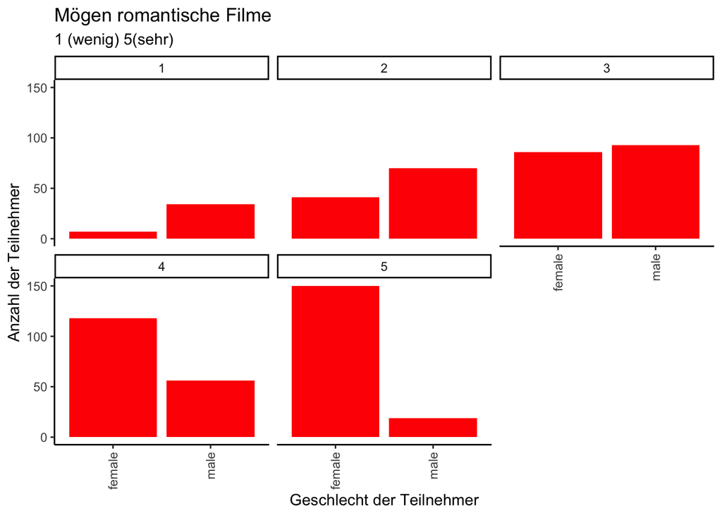

```r
ggplot(df, aes( x = Gender)) + # Entfernung von fill
  geom_bar( position = "dodge", fill= "red") +
  facet_wrap(~ df$`Romantic` ) + # Getrennte Darstellung der Ausprägungen
  ggtitle("Mögen romantische Filme", "1 (wenig) 5(sehr)") +
  xlab("Geschlecht der Teilnehmer") +
  ylab("Anzahl der Teilnehmer") +
  theme_classic() +
  theme(legend.title = element_blank()) +
  theme(axis.text.x = element_text(angle = 90,
                                   vjust = 0.5,
                                   hjust=  1))
```

Präferenz romantische Filme nach Geschlecht: Das Schaublid zeigt sehr deutlich, dass Frauen in den höheren Kategorien (4 und 5) hoch vertreten sind. Das heißt, dass sie romantische Filme mehr als Männer mögen, da diese in den Kategorien 4 und 5 deutlich den Frauen unterlegen. Sie dominieren dafür in den niedrigeren Kategorien, also kann man schlussfolgern, dass Männer nicht so gerne romantische Filme anschauen.

# Stacked Barplot

## Stacked Barplot 1

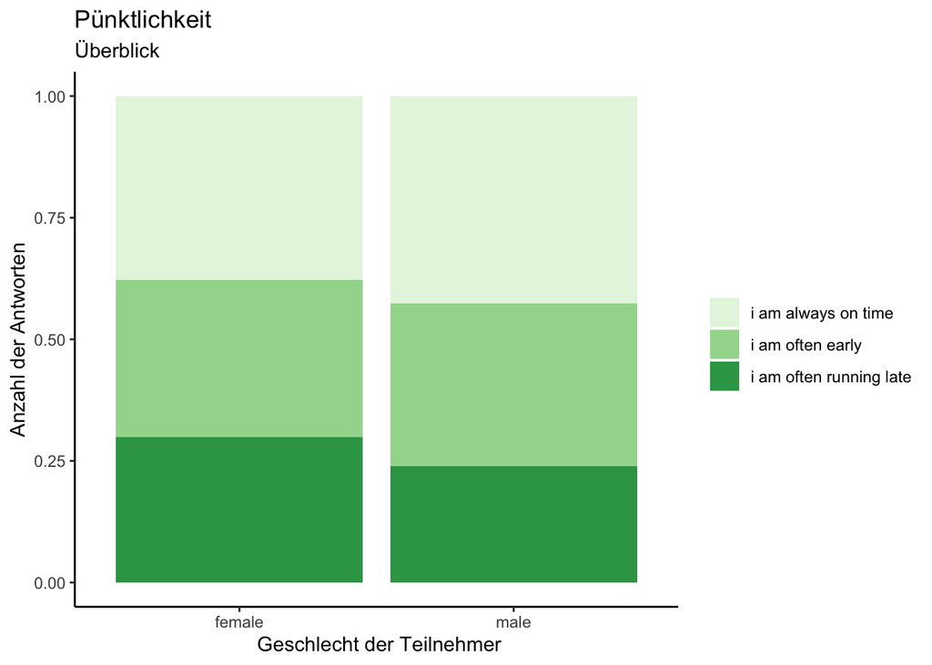

```r
ggplot(df, aes(   x = Gender,
                 fill = Punctuality)) +
  geom_bar( position = "fill") + # Änderung der Darstellung
  ggtitle("Pünktlichkeit", "Überblick") +
  xlab(" Geschlecht der Teilnehmer") +
  ylab("Anzahl der Antworten") +
  theme_classic() +
  scale_fill_brewer(palette = "Greens") +
  theme(legend.title = element_blank())
```

Pünktlichkeit nach Geschlecht: die meisten der Frauen gaben an, dass sie immer pünktlich sind. Wobei es einen kleinen Unterschied zu den Männern gibt. Es gaben nämlich mehr Männer als Frauen an immer pünktlich zu sein. Beide Geschlechter sind gleich übeerpünktlich. Allerdings haben mehr Frauen als Männer mit der Zeit zu kämpfen und sind öfter spät dran als Männer.

## Stacked Barplot 2

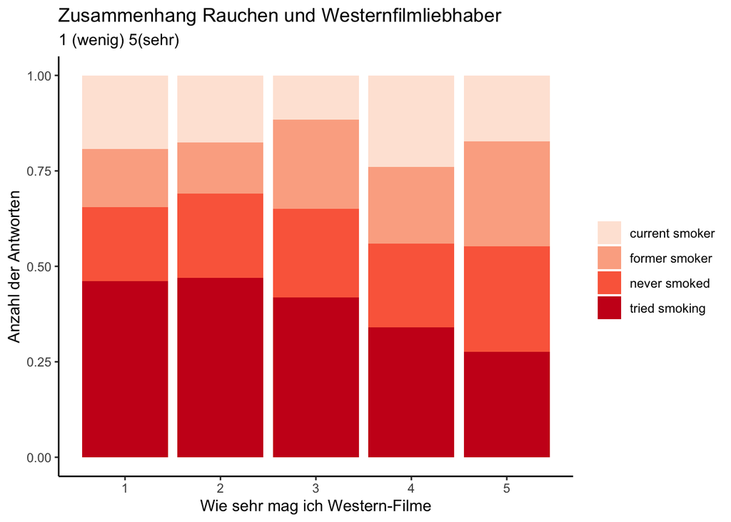

```r
ggplot(df, aes(   x = Western,
                 fill = Smoking)) +
  geom_bar( position = "fill") + # Änderung der Darstellung
  ggtitle("Zusammenhang Rauchen und Westernfilmliebhaber", "1 (wenig) 5(sehr)") +
  xlab("Wie sehr mag ich Western-Filme") +
  ylab("Anzahl der Antworten") +
  theme_classic() +
  scale_fill_brewer(palette = "Reds") +
  theme(legend.title = element_blank())
```

Raucher und Westernfilmliebhaber: Es gibt kaum große Unterschiede zwischen wie gerne man raucht und gleichzeitig Westernfilme liebt. Man kann lediglich erkennen dass mehr Menschen die das Rauchen ausprobiert haben eher weniger Westernfilme mag während Menschen die früher geraucht haben eher Westernfilme interessieren.

# Side by Side Barplot

## Side by Side Barplot 1

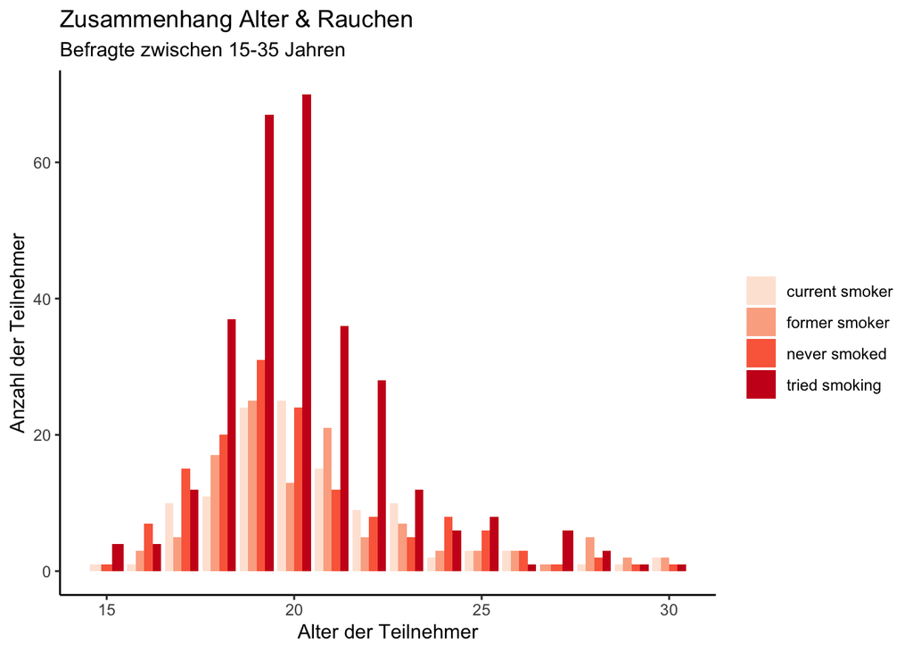

```r
ggplot(df, aes(   x = Age,
                 fill = Smoking)) +
  geom_bar( position = "dodge") +
  ggtitle("Zusammenhang Alter & Rauchen", "Befragte zwischen 15-35 Jahren") +
  xlab("Alter der Teilnehmer") +
  ylab("Anzahl der Teilnehmer") +
  theme_classic() +
  scale_fill_brewer(palette = "Reds") +
  theme(legend.title = element_blank())
```

## Side by Side Barplot 2

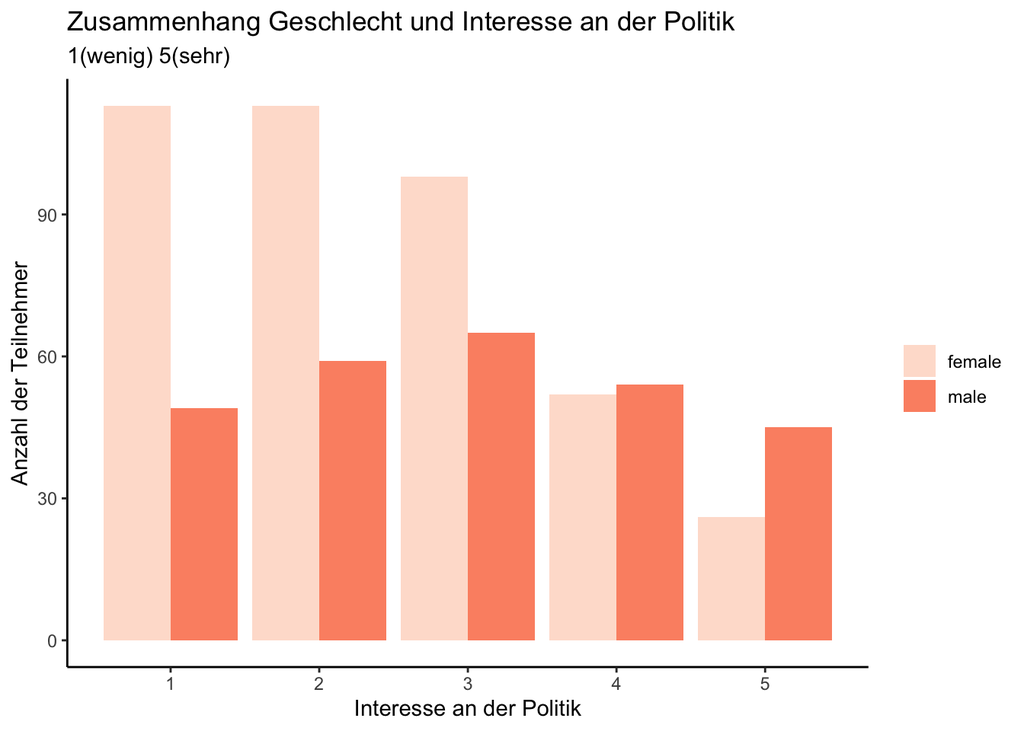

```r
ggplot(df, aes(   x = Politics,
                 fill = Gender)) +
  geom_bar( position = "dodge") +
  ggtitle("Zusammenhang Geschlecht und Interesse an der Politik", "1(wenig) 5(sehr)") +
  xlab("Interesse an der Politik") +
  ylab("Anzahl der Teilnehmer") +
  theme_classic() +
  scale_fill_brewer(palette = "Reds") +
  theme(legend.title = element_blank())
```

Die meisten Frauen gaben an, ein geringes mit mittelmäßiges Interesse an Politik zu haben währed die Männer gleich wenig und viel Interesse an der Politik zeigen. Allerdings hat eine Mehrheit der Männer eher ein mittelmäßiges Interesse an Politik. Trotzdem sind Männer ein wenig interessierter an Politik als Frauen.

# Boxplot

## Boxplot 1

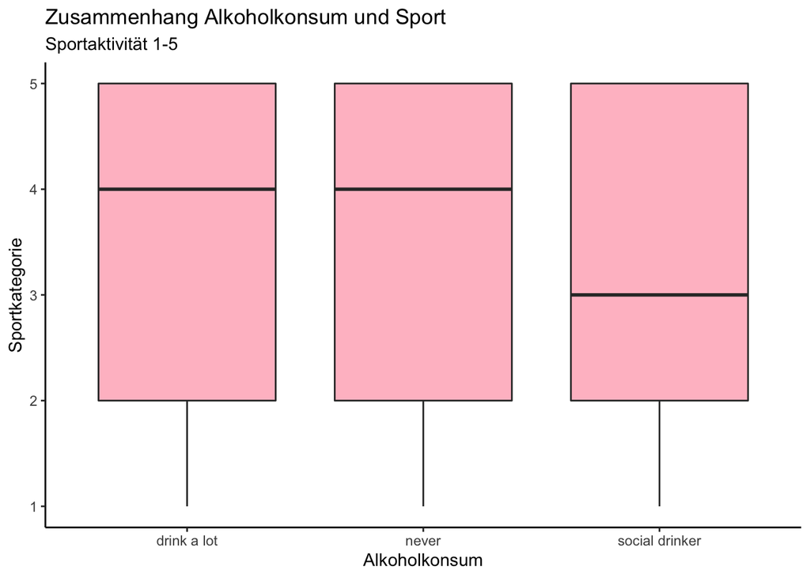

```r
ggplot(df, aes( x = Alcohol, # kategoriale Variable
                  y= df$`Active sport`)) + # numerische Variable
  geom_boxplot(fill ="pink", position = "dodge") +
  ggtitle("Zusammenhang Alkoholkonsum und Sport", "Sportaktivität 1-5") +
  xlab("Alkoholkonsum") +
  ylab("Sportkategorie") +
  theme_classic()
```

## Boxplot 2

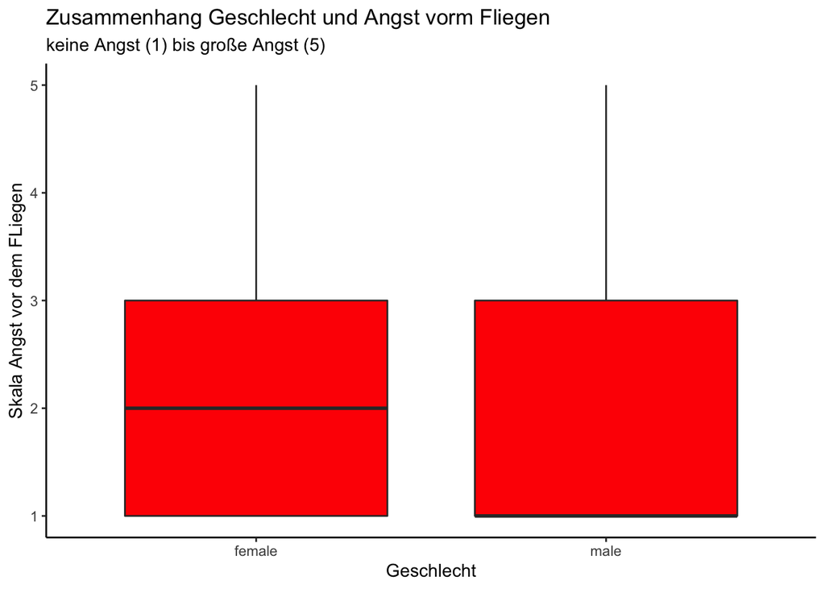

```r
ggplot(df, aes( x =Gender, # kategoriale Variable
                  y= df$`Flying`)) + # numerische Variable
  geom_boxplot(fill ="red", position = "dodge") +
  ggtitle("Zusammenhang Geschlecht und Angst vorm Fliegen", "keine Angst (1) bis große Angst (5)") +
  xlab("Geschlecht") +
  ylab("Skala Angst vor dem FLiegen") +
  theme_classic()
```

Beide Geschlechter haben wenig Angst vor dem Fliegen. Man kann erkennen dass Männer noch weniger Angst haben als Frauen da bei ihnen der Median bei 1 statt bei 2 liegt.

# Faceted Histogramm

## Faceted Histogramm 1

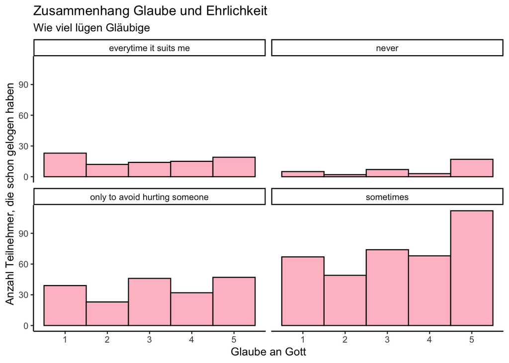

```r
ggplot(df, aes( x = God)) +
  geom_histogram(fill ="pink", binwidth = 1, color = "black")+
  facet_wrap(~Lying) +
  ggtitle("Zusammenhang Glaube und Ehrlichkeit", "Wie viel lügen Gläubige") +
  xlab("Glaube an Gott") +
  ylab("Anzahl Teilnehmer, die schon gelogen haben") +
  theme_classic()
```

Gläubige Menschen lügen am häufigsten wenn sie jemanden nicht verletzen wollen oder nur manchmal. Die wenigsten lügen nie.

## Faceted Histogramm 2

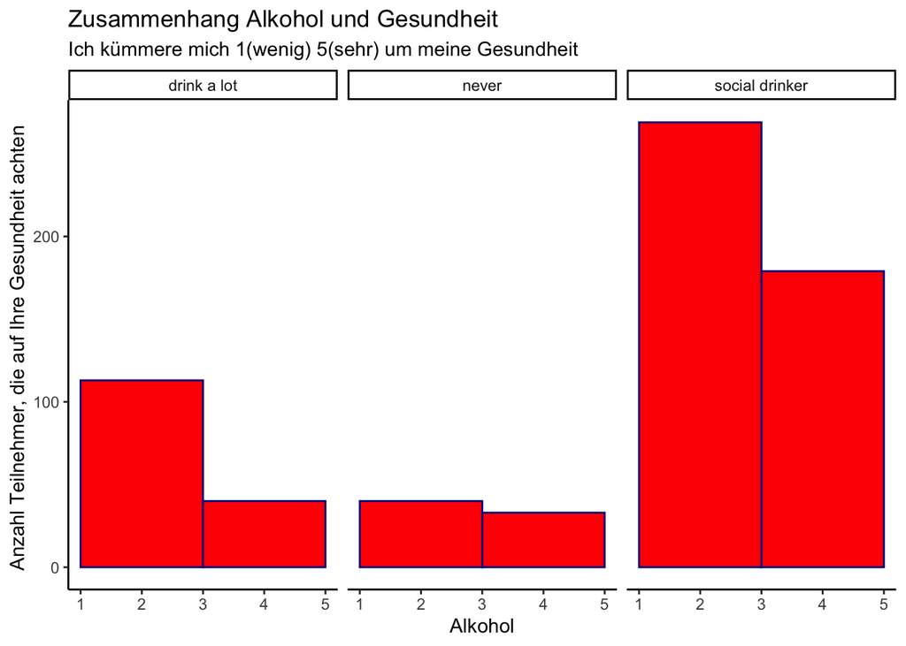

```r
ggplot(df, aes( x = Health)) +
  geom_histogram(fill ="red", binwidth = 2, color = "darkblue")+
  facet_wrap(~Alcohol) +
  ggtitle("Zusammenhang Alkohol und Gesundheit", "Ich kümmere mich 1(wenig) 5(sehr) um meine Gesundheit") +
  xlab("Alkohol") +
  ylab("Anzahl Teilnehmer, die auf Ihre Gesundheit achten ") +
  theme_classic()
```

# Scatterplot

## Scatterplot 1

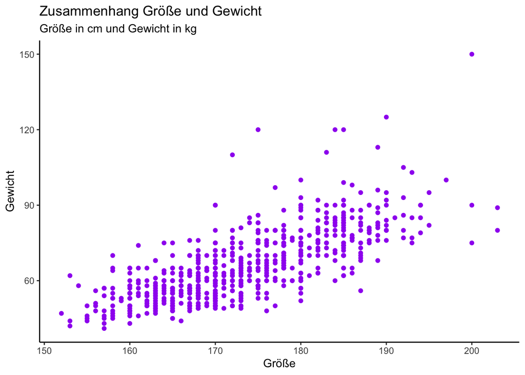

```r
ggplot(df, aes( x= Height,
                y= Weight)) +
         geom_point( color ="purple") +
  ggtitle("Zusammenhang Größe und Gewicht", "Größe in cm und Gewicht in kg") +
  xlab("Größe") +
  ylab("Gewicht") +
  theme_classic()
```

Man sieht gut, dass das Gewicht mit der Größe zunimmt. Allerdings sind die Daten ab ca. 185cm verstreut und liegen nicht mehr eng beieinander. Wir schließen daraus, dass die meisten Teilnehmer bis ca. 185cm groß ist und die meisten bis zu 80kg wiegen.

## Scatterplot 2

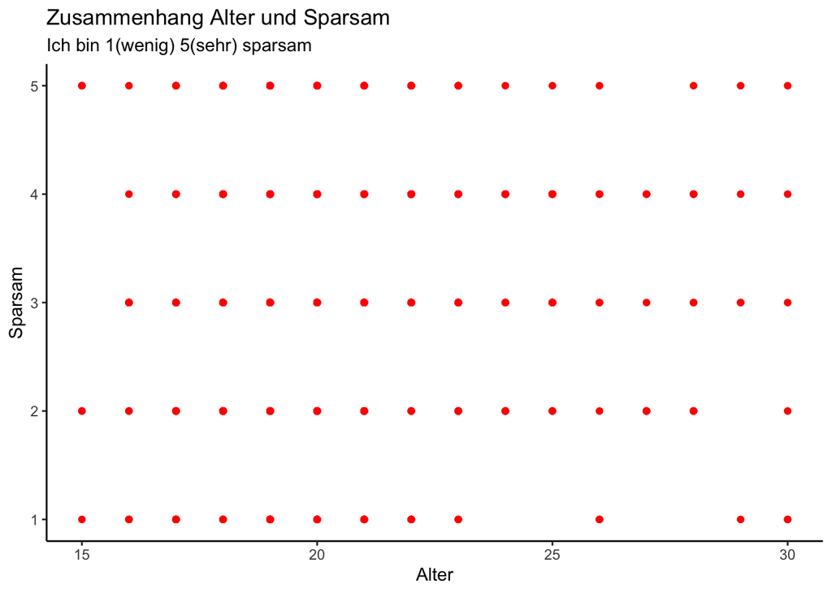

```r
ggplot(df, aes( x= Age,
                y= Finances)) +
         geom_point( color ="red") +
  ggtitle("Zusammenhang Alter und Sparsam", "Ich bin 1(wenig) 5(sehr) sparsam") +
  xlab("Alter") +
  ylab("Sparsam") +
  theme_classic()
```

# Line Graph

## Line Graph 1

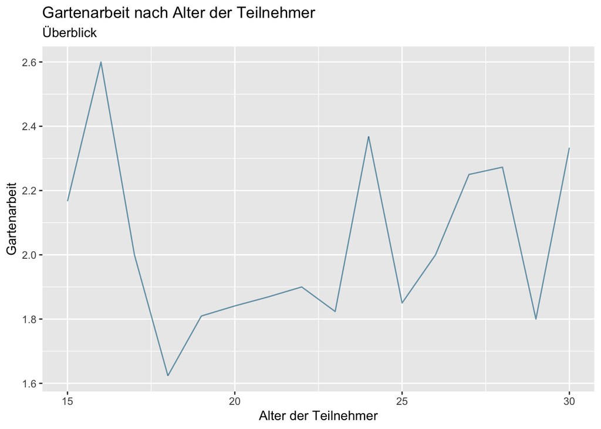

```r
df <-     # Speichern des Ergebnisses
  df %>%  # Nutzung der Daten aus df
  group_by(Age) %>%  # Gruppierung der Daten nach Alter
  mutate(mean_Gardening = mean(Gardening, na.rm = TRUE)) %>%  # Berechnung Mittelwert pro Gruppe und Erzeugung der neuen Variable mean_wage
  ungroup() # Gruppierung wieder aufheben


ggplot(df, aes( x = Age,
                y = mean_Gardening)) +
  geom_line(alpha=0.6, color="deepskyblue4")+
  ggtitle("Gartenarbeit nach Alter der Teilnehmer", "Überblick") +
  xlab("Alter der Teilnehmer") +
  ylab("Gartenarbeit")
```

```r
  theme_classic()
```

[output not shown]

[output cut: 356 more lines]

[output not shown]

## Line Graph 2

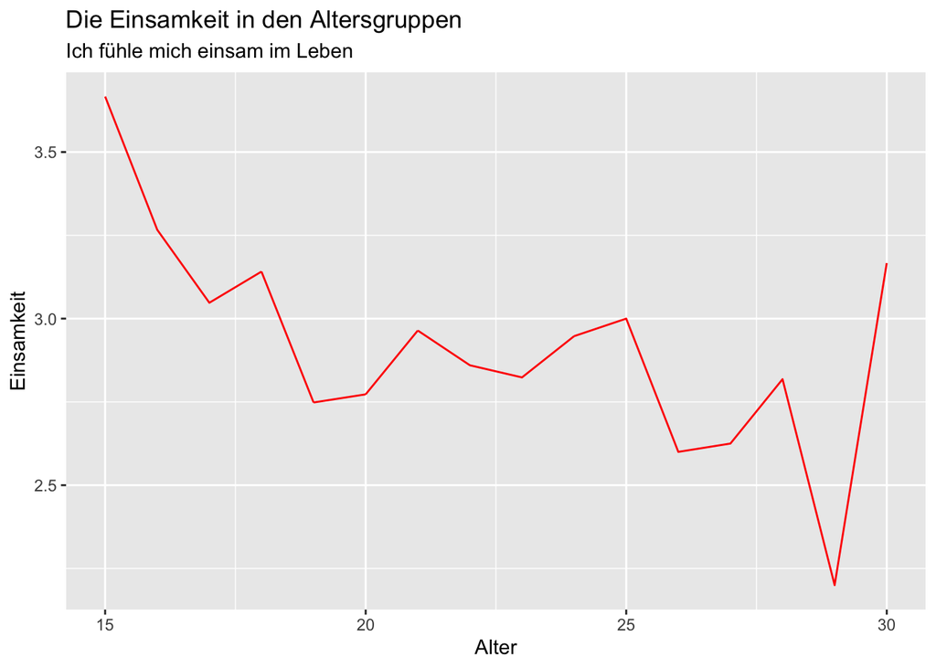

```r
df <-     # Speichern des Ergebnisses
  df %>%  # Nutzung der Daten aus wage
  group_by(`Age`) %>%  # Gruppierung der Daten nach Alter
  mutate(mean_Loneliness = mean(Loneliness, na.rm = TRUE)) %>%  # Berechnung Mittelwert pro Gruppe und Erzeugung der neuen Variable mean_wage
  ungroup() # Gruppierung wieder aufheben
ggplot(df, aes( x =Age,
                y = mean_Loneliness)) +
  geom_line(alpha=1, color="red")+
  ggtitle("Die Einsamkeit in den Altersgruppen", "Ich fühle mich einsam im Leben") +
  xlab("Alter") +
  ylab("Einsamkeit")
```

```r
  theme_classic()
```

[output not shown]

[output cut: 356 more lines]

[output not shown]

Man kann erkennen, dass die die jüngsten Teilnehmer am Einsamsten fühlen. dann sinkt die Kurve mit kleinen Anstiegen zwischendrin und geht am Ende wieder hoch. An dem Punkt der 29-Jährigen kann man sehen dass die Teilnehmer kaum bis gar nicht sich einsam fühlen. Zwischen den Jahren 20 und 25 kann man wenig Unterschiede erkennen.